# Personal Information

Name: Maja Murawka

StudentID: **13755129**

Email: **maja.murawka@student.uva.nl**

Github: majmurm/predicting-science-at-risk

Submitted on: **23.03.2026**

# Data Context

> Research Question: **To what extent can the risk of adverse outcomes for publicly funded research be predicted using textual and metadata features?**

This EDA convers data used to predict the vulnerability of publically funded research in the United States to adverse political outcomes - specifically, grant termination and dataset deletion. The context is the ongoing disruption to U.S. federal data infrastructure under the Trump administration, where executive orders have led to removal of datasets, restriction of access to federal web pages, and terminations of research grants at agencies including the National Institutes of Health (NIH), National Science Foundation (NSF), Environmental Protection Agency (EPA), Centres for Disease Control and Prevention (CDC), and Substance Abuse and Mental Health Services Administration (SAMHSA).

# Data Description

Two primary sources are used.

The first is the [Grant Witness](https://grant-witness.us) website, which tracks defunded federal research grants and provides structured metadata such as titles, abstracts, award amounts, activity dates, and termination status. Grant Witness aggregates their data from multiple independent sources, including submissions from affected scientists, news reports, official agency websites, and public budget estimations.

The second is the [Data Rescue Project (DRP) Portal](https://portal.datarescueproject.org), a volunteer-led archive of federal datasets considered at risk of deletion. DRP metadata was scraped from the project's [Github repository](https://github.com/datarescueproject/portal/) using `requests` library. Their actions are based on tips from researchers or other stakeholders, focused on agencies targeted in Project 2025 or in a presidential executive order.

```python
# Imports
import os
import warnings
import numpy as np
import pandas as pd
import seaborn as sns
import matplotlib.pyplot as plt
from matplotlib.lines import Line2D

from urllib.parse import urlparse
from sklearn.manifold import TSNE
sns.set_theme(style='whitegrid')

warnings.filterwarnings('ignore', category=FutureWarning, module='seaborn')
warnings.filterwarnings('ignore', category=PendingDeprecationWarning, module='seaborn')
```

```python
from IPython.display import display, HTML
display(HTML("""
<style>
    table { font-size: 9px !important; border-collapse: collapse; }
    th, td { padding: 2px 6px !important; white-space: nowrap; }
    @media print {
        table { font-size: 7px !important; }
        th, td { padding: 1px 4px !important; }
    }
</style>
"""))
```

## Data Loading

### Grant Witness

The Grant Witness dataset was created by stacking datasets from five federal agencies (CDC, EPA, NIH, NSF, SAMHSA) on shared columns:

- status,
- title,
- abstract,
- award amounts,
- termination details.

Each row represents a grant within an agency.

I manually adjusted small naming inconsistencies (for example, `organization` to `org_name`, or `award_value` to `award_amount`). The resulting dataframe consists of 12,156 rows.

The figure below represents data preprocessing performed on Grant Witness dataset:

[figure not shown]

```python
#GW
df_gw = pd.read_csv('grant_witness/00_data/df_full.csv')
print(df_gw.shape)
df_gw.head(5)
```

```
(12156, 41)
```

|  | Unnamed: 0 | abstract | agency | award_amount | award_outlaid | award_remaining | embeddings_abstract_allminilm | embeddings_title_allminilm | flagged_words_all | flagged_words_all_title | ... | org_name | org_state | project_title | reinstatement_date | reinstatement_indicator | start_date_original | status | termination_date | usaspending_url | target_adverse |
| --- | --- | --- | --- | --- | --- | --- | --- | --- | --- | --- | --- | --- | --- | --- | --- | --- | --- | --- | --- | --- | --- |
| 0 | 0 | NaN | NIH | 69867044.0 | 26075910.60 | 43791133.40 | [-1.18838333e-01 4.82986905e-02 -2.54816213e-... | [-1.18838392e-01 4.82986607e-02 -2.54813419e-... | NaN | NaN | ... | NaN | NaN | NaN | NaN | NaN | 2025-04-14 | Unfrozen Funding | NaN | https://www.usaspending.gov/award/ASST_NON_AY2... | 0 |
| 1 | 1 | NaN | NIH | 15533132.0 | 9874704.00 | 5658428.00 | [-1.18838333e-01 4.82986905e-02 -2.54816213e-... | [-1.18838392e-01 4.82986607e-02 -2.54813419e-... | NaN | NaN | ... | NaN | NaN | NaN | NaN | NaN | 2025-04-08 | Unfrozen Funding | NaN | https://www.usaspending.gov/award/ASST_NON_AY2... | 0 |
| 2 | 2 | NaN | NIH | 22010380.0 | 3884147.00 | 18126233.00 | [-1.18838333e-01 4.82986905e-02 -2.54816213e-... | [-1.18838392e-01 4.82986607e-02 -2.54813419e-... | NaN | NaN | ... | NaN | NaN | NaN | NaN | NaN | 2025-04-14 | Possibly Unfrozen Funding | NaN | https://www.usaspending.gov/award/ASST_NON_AY2... | 0 |
| 3 | 3 | PROJECT SUMMARY This institutional grant propo... | NIH | 8000000.0 | 8000000.00 | 0.00 | [-7.46721849e-02 -1.63383186e-02 -8.39300230e-... | [ 2.89413780e-02 -9.00794938e-03 -1.17702693e-... | institutional; trans | institutional | ... | COLUMBIA UNIVERSITY HEALTH SCIENCES | NY | Creation of an Institutional Biobanking Facility | 2025-04-11 | Removed from TAGGS list | NaN | Possibly Reinstated | 2025-03-12 | https://www.usaspending.gov/award/ASST_NON_C06... | 0 |
| 4 | 4 | Project Summary/Abstract Wards 7 and 8 in Wash... | NIH | 2000000.0 | 618137.31 | 1381862.69 | [-1.29834609e-02 2.11151000e-02 -1.03895999e-... | [-7.13748438e-03 -1.92470825e-03 -1.94740444e-... | community; inequities; integration; marginaliz... | community | ... | WHITMAN-WALKER INSTITUTE, INC. | DC | Developing a Community-Based Facility to Suppo... | 2025-08-08 | Removed from TAGGS list | NaN | Possibly Reinstated | 2025-03-21 | https://www.usaspending.gov/award/ASST_NON_C06... | 0 |

5 rows × 41 columns

### Data Rescue Project

The DRP data was scraped from the DRP Github repository using `requests` library. The original dataset consists of 2,972 entries, and each row represents a dataset rescued by DRP. It includes metadata columns: file title, organisation, agency, websites, data source, description, last modification date, category, url, format, status, donwload date, notes, and maintainer.

```python
df_drp_scraped = pd.read_csv('data_rescue_project/00_data/df_scraped.csv')
df_drp_scraped.head(5)
```

|  | Unnamed: 0 | Unnamed: 0_x | file | schema | title | organization | agency | websites | data_source | description | ... | Unnamed: 0_y | project_title | id | url | format | status | size | download_date | maintainer | notes |
| --- | --- | --- | --- | --- | --- | --- | --- | --- | --- | --- | --- | --- | --- | --- | --- | --- | --- | --- | --- | --- | --- |
| 0 | 0 | 0 | _datasets/10j-injunctions.md | data_rescue_project | 10(j) Injunctions | National Labor Relations Board | National Labor Relations Board | nlrb.gov | https://www.nlrb.gov/what-we-do/investigate-ch... | NaN | ... | 0 | 10(j) Injunctions | 759 | https://doi.org/10.3886/E226824V1 | CSV, TXT | Finished | 0.0000 | 2025-04-07 | DRP, DL | Section 10(j) of the National Labor Relations ... |
| 1 | 1 | 1 | _datasets/1998-2023-serotype-data-for-invasive... | data_rescue_project | 1998-2023 Serotype Data for Invasive Pneumococ... | Centers for Disease Control and Prevention (CDC) | Department of Health and Human Services | data.cdc.gov | https://data.cdc.gov/Public-Health-Surveillanc... | NaN | ... | 1 | 1998-2023 Serotype Data for Invasive Pneumococ... | 2256 | https://www.datalumos.org/datalumos/project/24... | PDF, CSV | Finished | 0.0009 | 2026-01-10 | DRP, DL | NaN |
| 2 | 2 | 2 | _datasets/2002-2024-mbda-grantees.md | data_rescue_project | 2002-2024 MBDA Grantees | Minority Business Development Agency | Department of Commerce | mbda.gov | https://www.mbda.gov/research/data/mbda-grantees | NaN | ... | 2 | 2002-2024 MBDA Grantees | 696 | https://www.datalumos.org/datalumos/project/22... | CSV | Finished | 0.0000 | 2025-03-18 | DRP, DL | NaN |
| 3 | 3 | 3 | _datasets/2006-iur-public-database.md | data_rescue_project | 2006 IUR Public Database | Environmental Protection Agency | Environmental Protection Agency | epa.gov | https://www.epa.gov/chemical-data-reporting/do... | NaN | ... | 3 | 2006 IUR Public Database | 1280 | https://dataverse.harvard.edu/dataset.xhtml?pe... | mhtml, ZIP, PDF | Finished | 0.0050 | 2025-02-26 | HD, CAFE-RCC | There was a 2006 version and a 2002-1986 versi... |
| 4 | 4 | 4 | _datasets/2013-2014-phap-associates-by-state.md | data_rescue_project | 2013-2014 PHAP Associates by State | Centers for Disease Control and Prevention (CDC) | Department of Health and Human Services | data.cdc.gov | https://data.cdc.gov/dataset/2013-2014-PHAP-As... | NaN | ... | 4 | 2013-2014 PHAP Associates by State | 2257 | https://www.datalumos.org/datalumos/project/24... | PDF, CSV | Finished | 0.0000 | 2026-01-13 | DRP, DL | NaN |

5 rows × 25 columns

Most of the metadata fields are related to republishing and maintenance, with little information on the datasets themselves (aside from title). Fields that could contain this information, like description or notes, or additional metadata, are mostly NaN values.

```python
df_drp_scraped.isna().mean().sort_values(ascending=False).head(10)
```

```
description      0.996692
metadata_url     0.953688
notes            0.718492
format           0.175984
size             0.105855
download_date    0.043004
url              0.014886
agency           0.000331
websites         0.000331
data_source      0.000331
dtype: float64
```

```python
df_drp_scraped[['description', 'notes', 'category', 'metadata_available']].head(5)
```

|  | description | notes | category | metadata_available |
| --- | --- | --- | --- | --- |
| 0 | NaN | Section 10(j) of the National Labor Relations ... | Labor & Employment | True |
| 1 | NaN | NaN | Health & Healthcare | False |
| 2 | NaN | NaN | Business & Economy | False |
| 3 | NaN | There was a 2006 version and a 2002-1986 versi... | Climate & Environment | True |
| 4 | NaN | NaN | Health & Healthcare | False |

Therefore, I decided to scrape any additional metadata from DataCite REST API. As only 49 datasets have an actual DOI as url, it was necessary to extract DOI from other urls (domains incl. DataLumos, Harvard Dataverse, Urban Data Catalog, Zenodo) using `regex`.

```python
df_drp_scraped["domain"] = df_drp_scraped["url"].apply(lambda u: urlparse(u).netloc if isinstance(u, str) else None)
df_drp_scraped['domain'].value_counts().head(5)
```

```
domain
www.datalumos.org        2586
www.dropbox.com            85
sciop.net                  72
doi.org                    49
dataverse.harvard.edu      46
Name: count, dtype: int64
```

This allowed to acquire additional metadata for a total of 2539 of 2970 DRP datasets (loaded as `df_drp`).

```python
df_drp = pd.read_csv('data_rescue_project/00_data/drp_withdoi.csv')
df_drp.drop(columns=['Unnamed: 0'], inplace=True)
df_drp.head(5)
```

|  | file | schema | title | organization | agency | websites | data_source | last_modified | metadata_available | category | ... | has_flagged_word_title | num_flagged_words_title | num_pen_words_title | num_nyt_words_title | n_banned_terms_title | num_flagged_words_total | num_pen_words_total | num_nyt_words_total | n_banned_terms_total | has_flagged_word_total |
| --- | --- | --- | --- | --- | --- | --- | --- | --- | --- | --- | --- | --- | --- | --- | --- | --- | --- | --- | --- | --- | --- |
| 0 | _datasets/10j-injunctions.md | data_rescue_project | 10(j) Injunctions | National Labor Relations Board | National Labor Relations Board | nlrb.gov | https://www.nlrb.gov/what-we-do/investigate-ch... | 2025-04-20 | True | Labor & Employment | ... | 0 | 0 | 0 | 0 | 0 | 1 | 0 | 1 | 1 | 1 |
| 1 | _datasets/1998-2023-serotype-data-for-invasive... | data_rescue_project | 1998-2023 Serotype Data for Invasive Pneumococ... | Centers for Disease Control and Prevention (CDC) | Department of Health and Human Services | data.cdc.gov | https://data.cdc.gov/Public-Health-Surveillanc... | 2026-01-25 | False | Health & Healthcare | ... | 0 | 0 | 0 | 0 | 0 | 1 | 1 | 0 | 1 | 1 |
| 2 | _datasets/2002-2024-mbda-grantees.md | data_rescue_project | 2002-2024 MBDA Grantees | Minority Business Development Agency | Department of Commerce | mbda.gov | https://www.mbda.gov/research/data/mbda-grantees | 2025-04-02 | False | Business & Economy | ... | 0 | 0 | 0 | 0 | 0 | 4 | 3 | 3 | 8 | 1 |
| 3 | _datasets/2006-iur-public-database.md | data_rescue_project | 2006 IUR Public Database | Environmental Protection Agency | Environmental Protection Agency | epa.gov | https://www.epa.gov/chemical-data-reporting/do... | 2025-09-18 | True | Climate & Environment | ... | 0 | 0 | 0 | 0 | 0 | 0 | 0 | 0 | 0 | 0 |
| 4 | _datasets/2013-2014-phap-associates-by-state.md | data_rescue_project | 2013-2014 PHAP Associates by State | Centers for Disease Control and Prevention (CDC) | Department of Health and Human Services | data.cdc.gov | https://data.cdc.gov/dataset/2013-2014-PHAP-As... | 2026-01-25 | False | Health & Healthcare | ... | 0 | 0 | 0 | 0 | 0 | 0 | 0 | 0 | 0 | 0 |

5 rows × 106 columns

The figure below provides an summary of preprocessing steps for DRP data:

[figure not shown]

### Feature engineering

As mentioned on the pipeline figures, both datasets were enriched with additional features based on presence of flagged words. Based on two banned words lists published by PEN and by NYT, the script analyses words in abstracts and titles, resulting in the following:

- binary flag for detected banned words: `has_flagged_word` / `has_flagged_word_title` / `has_flagged_word_total`,
- total number of banned words: `n_banned_terms` / `n_banned_terms_title` / `n_banned_terms_total`,
- lists of unique banned words: `flagged_words_pen` / `flagged_words_pen_title`, `flagged_words_nyt` / `flagged_words_nyt_title`, `flagged_words_all` / `flagged_words_all_title`,
- number of unqiue banned words: `num_flagged_words` / `num_flagged_words_title` / `num_flagged_words_total`, `num_pen_words` / `num_pen_words_title` / `num_pen_words_total`, `num_nyt_words` / `num_nyt_words_title` / `num_nyt_words_total`.

Embeddings for titles and abstracts were generated using all-MiniLM-L6-v2, a sentence transformed model. They are stored in columns `embeddings_abstract_allminilm` and `embeddings_title_allminilm`.

## Grant Witness

### Analysis 1: Missing data

```python
missing_by_agency = df_gw.groupby('agency').apply(lambda g: g.isna().mean())
missing_by_agency = missing_by_agency.loc[:, (missing_by_agency > 0).any()]
missing_by_agency.T.style.format('{:.1%}').background_gradient(cmap='BuPu')
```

| agency | CDC | EPA | NIH | NSF | SAMHSA |
| --- | --- | --- | --- | --- | --- |
| abstract | 100.0% | 0.0% | 0.4% | 0.3% | 8.9% |
| award_amount | 0.6% | 0.0% | 0.3% | 0.2% | 0.1% |
| award_outlaid | 2.2% | 11.3% | 1.2% | 0.1% | 4.4% |
| award_remaining | 2.2% | 11.3% | 1.2% | 0.1% | 4.4% |
| embeddings_abstract_allminilm | 100.0% | 0.0% | 0.0% | 0.0% | 0.0% |
| flagged_words_all | 100.0% | 6.1% | 5.5% | 8.0% | 11.2% |
| flagged_words_all_title | 59.0% | 76.2% | 78.6% | 50.2% | 54.7% |
| flagged_words_nyt | 100.0% | 23.5% | 30.0% | 13.4% | 15.4% |
| flagged_words_nyt_title | 85.4% | 93.0% | 83.4% | 57.9% | 58.5% |
| flagged_words_pen | 100.0% | 6.1% | 19.4% | 8.0% | 11.2% |
| flagged_words_pen_title | 59.0% | 76.2% | 78.8% | 50.3% | 54.7% |
| org_city | 0.0% | 0.0% | 0.3% | 0.3% | 0.0% |
| org_name | 0.0% | 0.0% | 0.3% | 0.2% | 0.0% |
| org_state | 0.4% | 0.0% | 0.5% | 0.2% | 0.0% |
| project_title | 0.0% | 0.0% | 0.3% | 0.2% | 0.0% |
| reinstatement_date | 56.1% | 88.4% | 56.8% | 68.3% | 4.6% |
| reinstatement_indicator | 56.1% | 88.5% | 56.8% | 68.3% | 4.6% |
| start_date_original | 0.6% | 0.0% | 50.8% | 0.2% | 0.1% |
| termination_date | 9.8% | 0.4% | 43.0% | 0.0% | 0.0% |
| usaspending_url | 0.6% | 0.0% | 0.0% | 0.0% | 0.1% |

Many columns have missing values across all agencies. For example `reinstatement_date` and `reinstatement_indicator` are only populated for grants that were reinstated or unfrozen, and `abstract` is entirely absent for CDC, which is why it has to be excluded for analysis of textual (abstract-based) features.

For other agencies the share of missing values in `abstract` column is insignificant.

```python
df_gw.groupby('agency')['abstract'].apply(lambda x: x.isna().mean())
```

```
agency
CDC       1.000000
EPA       0.000000
NIH       0.004322
NSF       0.002505
SAMHSA    0.089389
Name: abstract, dtype: float64
```

```python
df_gw['abstract_word_count'] = df_gw['abstract'].fillna('').astype(str).str.split().str.len()
df_gw['title_word_count'] = df_gw['project_title'].fillna('').astype(str).str.split().str.len()
df_gw_nona = df_gw.loc[df_gw['abstract'].notna()].copy()

desc = pd.concat([df_gw['title_word_count'].describe(), df_gw['abstract_word_count'].describe(), df_gw_nona['abstract_word_count'].describe()], axis=1)
desc.columns = ['title_wc_all', 'abstract_wc_all', 'abstract_wc_no_na']
desc
```

|  | title_wc_all | abstract_wc_all | abstract_wc_no_na |
| --- | --- | --- | --- |
| count | 12156.000000 | 12156.000000 | 11321.000000 |
| mean | 10.728858 | 369.085884 | 396.308453 |
| std | 4.875921 | 150.138454 | 115.822304 |
| min | 0.000000 | 0.000000 | 2.000000 |
| 25% | 7.000000 | 313.000000 | 335.000000 |
| 50% | 10.000000 | 405.000000 | 414.000000 |
| 75% | 14.000000 | 458.000000 | 462.000000 |
| max | 32.000000 | 3285.000000 | 3285.000000 |

Titles word counts in GW have a mean of 10.7, and min of 0 and maximum of 32. For abstracts (on the full GW df, including NaN values) the mean word count is 369 with standard deviation of 150, and with exclusion of NaN values - 396 with standard deviation of 116.

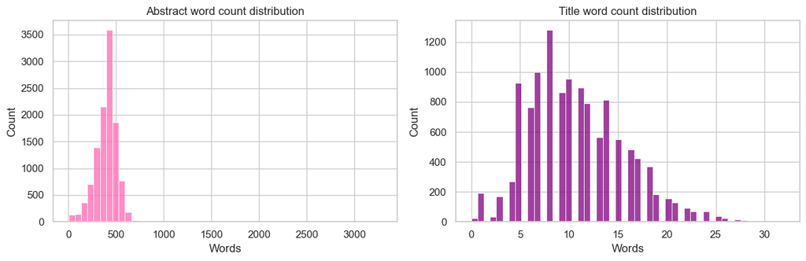

```python
fig, axes = plt.subplots(1, 2, figsize=(12, 4))
sns.histplot(data=df_gw_nona, x='abstract_word_count', bins=50, ax=axes[0], color='hotpink')
axes[0].set_title('Abstract word count distribution')
axes[0].set_xlabel('Words')
sns.histplot(data=df_gw, x='title_word_count', bins=50, ax=axes[1], color='purple')
axes[1].set_title('Title word count distribution')
axes[1].set_xlabel('Words')
plt.tight_layout()
plt.show()
```

```python
print((df_gw_nona['abstract_word_count'] > 1000).value_counts())
print((df_gw_nona['title_word_count'] > 25).value_counts())
```

```
abstract_word_count
False    11317
True         4
Name: count, dtype: int64
title_word_count
False    11276
True        45
Name: count, dtype: int64
```

Abstract word counts (excl. Nan) have a right-skewed distribution with a peak around 400-500 words, and most abstracts are between 200-700 words. There's a tail extending up to 3000 words, but only 4 abstracts are above 1000. This might be due to a word limit for grant descriptions/abstracts.

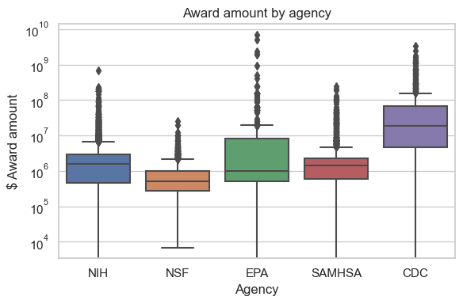

```python
fig, ax = plt.subplots(figsize=(6, 4))
sns.boxplot(data=df_gw.dropna(subset=['award_amount']), x='agency', y='award_amount', ax=ax)
ax.set_yscale('log')
ax.set_title('Award amount by agency')
ax.set_xlabel('Agency')
ax.set_ylabel('$ Award amount')
plt.tight_layout()
plt.show()
```

Award amounts are highest in CDC, with a wide spread. EPA has the most diverse amounts. All agencies also have some extreme outliers.

```python
df_gw[['award_amount']].describe().T.style.format('{:,.2f}')
```

|  | count | mean | std | min | 25% | 50% | 75% | max |
| --- | --- | --- | --- | --- | --- | --- | --- | --- |
| award_amount | 12,130.00 | 10,027,376.95 | 108,581,921.73 | -125,000.00 | 466,125.00 | 1,285,007.00 | 2,650,576.00 | 6,970,000,000.00 |

We can see that award_amount has a huge range = mean of 10m USD and standard deviation of 109m USD. A maximum value is 7 billion USD, which is probably an institutional grant. Interestingly, there's a negative minimum, meaning there could be some corrections in the data. A median of 1.3m USD is likely more representative than the mean.

### Flagged words

Analysis only on df_gw_nona (without null abstracts).

```python
df_gw_nona[['num_flagged_words', 'num_flagged_words_title', 'num_flagged_words_total']].describe().T.style.format('{:,.2f}')
```

|  | count | mean | std | min | 25% | 50% | 75% | max |
| --- | --- | --- | --- | --- | --- | --- | --- | --- |
| num_flagged_words | 11,321.00 | 5.36 | 4.26 | 0.00 | 2.00 | 4.00 | 8.00 | 32.00 |
| num_flagged_words_title | 11,321.00 | 0.49 | 0.84 | 0.00 | 0.00 | 0.00 | 1.00 | 12.00 |
| num_flagged_words_total | 11,321.00 | 5.85 | 4.72 | 0.00 | 2.00 | 4.00 | 8.00 | 38.00 |

```python
flag_cols = [c for c in df_gw_nona.columns if c.startswith(('has_flagged', 'num_flagged', 'num_pen', 'num_nyt', 'n_banned'))]
summary = df_gw_nona.groupby('agency')[flag_cols].mean()
summary.insert(0, 'rows', df_gw_nona.groupby('agency').size())
for col in [c for c in flag_cols if c.startswith('has_flagged')]:
    summary[col] *= 100
summary
```

| agency | rows | has_flagged_word | has_flagged_word_title | has_flagged_word_total | n_banned_terms | n_banned_terms_title | n_banned_terms_total | num_flagged_words | num_flagged_words_title | num_flagged_words_total | num_nyt_words | num_nyt_words_title | num_nyt_words_total | num_pen_words | num_pen_words_title | num_pen_words_total |
| --- | --- | --- | --- | --- | --- | --- | --- | --- | --- | --- | --- | --- | --- | --- | --- | --- |
| EPA | 671 | 93.889717 | 23.845007 | 94.485842 | 18.146051 | 0.406855 | 18.552906 | 5.774963 | 0.321908 | 6.096870 | 2.068554 | 0.081967 | 2.150522 | 5.730253 | 0.321908 | 6.052161 |
| NIH | 5990 | 94.891486 | 21.452421 | 94.941569 | 9.602671 | 0.570117 | 10.172788 | 4.435392 | 0.321035 | 4.756427 | 2.216528 | 0.243573 | 2.460100 | 2.981636 | 0.317863 | 3.299499 |
| NSF | 1991 | 92.265193 | 49.924661 | 92.415871 | 24.081868 | 1.485183 | 25.567052 | 7.029633 | 0.811652 | 7.841286 | 5.442993 | 0.645404 | 6.088398 | 6.922150 | 0.809141 | 7.731291 |
| SAMHSA | 2669 | 97.564631 | 48.482578 | 97.677033 | 21.009741 | 1.297115 | 22.306857 | 6.099288 | 0.675534 | 6.774822 | 3.841139 | 0.539903 | 4.381042 | 5.999625 | 0.675534 | 6.675159 |

### Target variable analysis

```python
counts_df = (
    df_gw_nona
    .groupby('agency')['status']
    .value_counts()
    .unstack(fill_value=0)
    .T
    .sort_index()
)

counts_df
```

| agency status | EPA | NIH | NSF | SAMHSA |
| --- | --- | --- | --- | --- |
| Frozen Funding | 0 | 157 | 0 | 0 |
| Possibly Reinstated | 10 | 2584 | 629 | 2604 |
| Possibly Unfrozen Funding | 0 | 951 | 0 | 0 |
| Reinstated | 54 | 0 | 0 | 24 |
| Terminated | 607 | 1192 | 1362 | 41 |
| Unfrozen Funding | 0 | 1106 | 0 | 0 |

```python
color_map = {
    "Terminated": "black",
    "Frozen Funding": "#4d4d4d",
    "Possibly Unfrozen Funding": "#9ecae1",
    "Unfrozen Funding": "#3182bd",
    "Possibly Reinstated": "#a1d99b",
    "Reinstated": "#006d2c",
    "At-risk": "#cccdd4",
}
status_order = ["Terminated", "Frozen Funding", "Possibly Unfrozen Funding", "Unfrozen Funding", "Possibly Reinstated", "Reinstated", "At-risk",]
counts_df = counts_df.reindex(status_order).fillna(0)
```

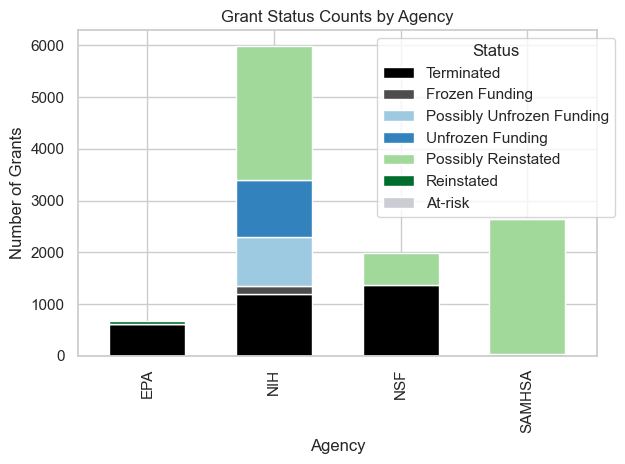

```python
fig, ax = plt.subplots()
counts_df.T.plot(
    kind='bar', stacked=True,
    color=[color_map[s] for s in counts_df.index],
    ax=ax, legend=False, width=0.6
)
ax.set_ylabel("Number of Grants")
ax.set_xlabel("Agency")
ax.set_title("Grant Status Counts by Agency")
ax.legend(counts_df.index, title="Status", bbox_to_anchor=(1.05, 1))
plt.tight_layout()
plt.show()
```

As the values are not uniform across the agencies, a single target binary `target_adverse` has been created - Terminated and Frozen fundings are clear adverse outcomes with value of 1, the other outcomes are 0.

```python
adverse_statuses = ['Terminated', 'Frozen Funding']

df_gw['target_adverse'] = df_gw['status'].isin(adverse_statuses).astype(int)
df_gw_nona['target_adverse'] = df_gw_nona['status'].isin(adverse_statuses).astype(int)
```

```python
df_gw_nona['target_adverse'].value_counts()
```

```
target_adverse
0    7962
1    3359
Name: count, dtype: int64
```

There is clear class imbalance, with non-adverse outcomes being 70% of the dataset.

```python
df_gw.groupby('agency')['target_adverse'].value_counts().unstack(fill_value=0).sort_index()
```

| target_adverse agency | 0 | 1 |
| --- | --- | --- |
| CDC | 291 | 251 |
| EPA | 64 | 607 |
| NIH | 4652 | 1364 |
| NSF | 633 | 1363 |
| SAMHSA | 2797 | 134 |

There are differences between agencies: EPA and NSF have high adverse rates, and SAMHSA and NIH are largely unaffected. Agency is a strong single predictor can mislead the model to predict not adverse and score a 70% accuracy, which would be a failure on EPA and NSF grants.

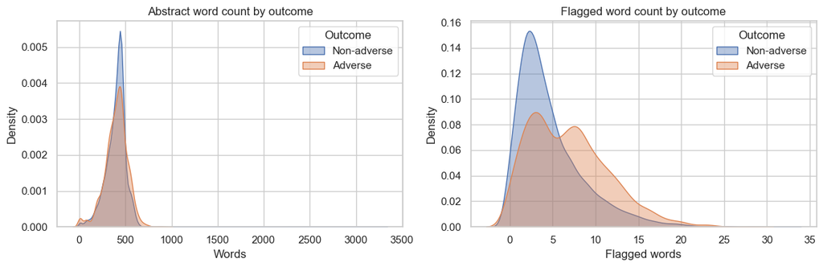

```python
fig, axes = plt.subplots(1, 2, figsize=(12, 4))

for val, label in [(0, 'Non-adverse'), (1, 'Adverse')]:
    subset = df_gw_nona[df_gw_nona['target_adverse'] == val]
    sns.kdeplot(data=subset, x='abstract_word_count', fill=True, alpha=0.4, label=label, ax=axes[0])
    sns.kdeplot(data=subset, x='num_flagged_words', fill=True, alpha=0.4, label=label, ax=axes[1])

axes[0].set_title('Abstract word count by outcome')
axes[0].set_xlabel('Words')
axes[0].legend(title='Outcome')

axes[1].set_title('Flagged word count by outcome')
axes[1].set_xlabel('Flagged words')
axes[1].legend(title='Outcome')

plt.tight_layout()
plt.show()
```

Abstract length looks almost the same for both outcomes. For flagged word counts there is a clear separation, with adverse grants having a flatter distribution. Non-adverse grants cluster around 2-3, and adverse ones spread above 10.

#### Do grants with flagged content get terminated more often?

```python
df_gw_nona.groupby('status')[['num_flagged_words', 'num_flagged_words_title']].mean()
```

| status | num_flagged_words | num_flagged_words_title |
| --- | --- | --- |
| Frozen Funding | 2.923567 | 0.108280 |
| Possibly Reinstated | 5.338596 | 0.521881 |
| Possibly Unfrozen Funding | 3.019979 | 0.129338 |
| Reinstated | 2.358974 | 0.538462 |
| Terminated | 7.088070 | 0.677077 |
| Unfrozen Funding | 3.073237 | 0.150995 |

Terminated grants have the highest number of banned words, and Frozen Funding and Reinstated have fewest. In titles, Terminated and (interestingly) Reinstated are the highest, with Possibly Unfrozen Funding, Unfrozen Funding and Frozen Funding being closest to 0.

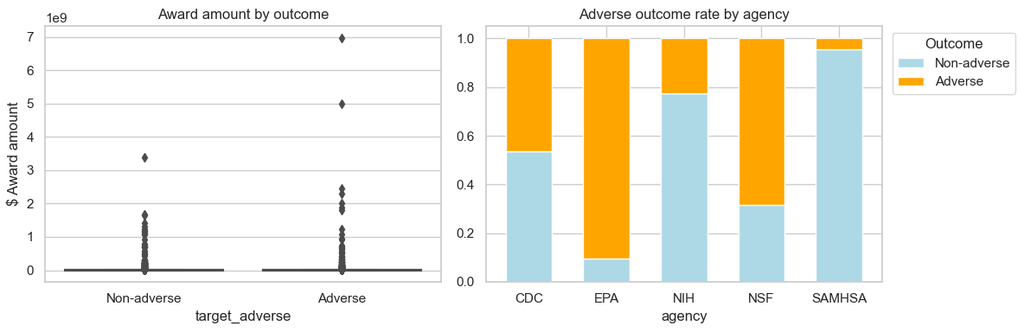

```python
fig, axes = plt.subplots(1, 2, figsize=(12, 4))

sns.boxplot(data=df_gw.dropna(subset=['award_amount']), x='target_adverse', y='award_amount', ax=axes[0])
axes[0].set_title('Award amount by outcome')
axes[0].set_xticklabels(['Non-adverse', 'Adverse'])
axes[0].set_ylabel('$ Award amount')

ct = pd.crosstab(df_gw['agency'], df_gw['target_adverse'], normalize='index')
ct.columns = ['Non-adverse', 'Adverse']
ct.plot(kind='bar', stacked=True, color=['lightblue', 'orange'], ax=axes[1], width=0.6)
axes[1].set_title('Adverse outcome rate by agency')
axes[1].tick_params(axis='x', rotation=0)
axes[1].legend(title='Outcome', bbox_to_anchor=(1.01, 1), loc='upper left')

plt.tight_layout()
plt.show()
```

Award amount is not a good signal for outcome - there is no clear separation. For agency, previously described patterns are confirmed.

#### What do embeddings reveal about the target variable?

```python
def parse_embedding(x):
    if isinstance(x, str):
        return np.fromstring(x.replace('\n', ' ').strip('[]'), sep=' ')
    return x

df_gw_nona.loc[:, 'embeddings_abstract_allminilm'] = df_gw_nona['embeddings_abstract_allminilm'].apply(parse_embedding)
df_gw_nona.loc[:, 'embeddings_title_allminilm'] = df_gw_nona['embeddings_title_allminilm'].apply(parse_embedding)
df_gw['embeddings_title_allminilm'] = df_gw['embeddings_title_allminilm'].apply(parse_embedding)
```

```python
n = 500
df_plot_abs = pd.concat([
    df_gw_nona[df_gw_nona['target_adverse'] == 1].sample(n, random_state=42),
    df_gw_nona[df_gw_nona['target_adverse'] == 0].sample(n, random_state=42),
])
X_abs = np.vstack(df_plot_abs['embeddings_abstract_allminilm'].tolist())
X_tsne_abs = TSNE(n_components=2, perplexity=30, random_state=42, init='pca', learning_rate='auto').fit_transform(X_abs)
df_plot_abs['tsne_x'] = X_tsne_abs[:, 0]
df_plot_abs['tsne_y'] = X_tsne_abs[:, 1]

df_plot_title = df_gw.dropna(subset=['embeddings_title_allminilm']).sample(1000, random_state=42).copy()
X_title = np.vstack(df_plot_title['embeddings_title_allminilm'].tolist())
X_tsne_title = TSNE(n_components=2, perplexity=30, random_state=42, init='pca', learning_rate='auto').fit_transform(X_title)
df_plot_title['tsne_x'] = X_tsne_title[:, 0]
df_plot_title['tsne_y'] = X_tsne_title[:, 1]
```

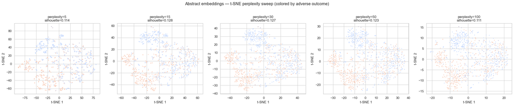

```python
from sklearn.metrics import silhouette_score

perplexities = [5, 15, 30, 50, 100]
X_abs_full = np.vstack(df_plot_abs['embeddings_abstract_allminilm'].tolist())
labels = df_plot_abs['target_adverse'].values

fig, axes = plt.subplots(1, len(perplexities), figsize=(5 * len(perplexities), 5))

for ax, perp in zip(axes, perplexities):
    X_tsne = TSNE(n_components=2, perplexity=perp, random_state=42,
                  init='pca', learning_rate='auto').fit_transform(X_abs_full)
    sil = silhouette_score(X_tsne, labels)
    sns.scatterplot(x=X_tsne[:, 0], y=X_tsne[:, 1],
                    hue=labels, palette='coolwarm', s=8, alpha=0.6,
                    ax=ax, legend=False)
    ax.set_title(f'perplexity={perp}\nsilhouette={sil:.3f}')
    ax.set_xlabel('t-SNE 1')
    ax.set_ylabel('t-SNE 2')

plt.suptitle('Abstract embeddings — t-SNE perplexity sweep (colored by adverse outcome)', y=1.02)
plt.tight_layout()
plt.show()
```

For t-SNE, silhouette scores for perplexities 5-100 are around 0.11-0.13, which means there is weak but stable separation. Embeddings might be a useful feature in combination with other features, not on their own.

## Data Rescue Project

```python
print(df_drp.shape)
```

```
(2539, 106)
```

DRP data with metadata from DataCite contains 2539 rows and 106 columns.

### Missing data

```python
missing = df_drp.isna().mean().sort_values(ascending=False)
print(f'{(missing > 0).sum()} / {len(missing)} columns have missing values')
missing.head(10).to_frame('missing_rate').style.format('{:.1%}')
```

```
25 / 106 columns have missing values
```

|  | missing_rate |
| --- | --- |
| dc_error | 100.0% |
| dc_rel_citations | 96.7% |
| flagged_words_nyt_title | 92.5% |
| flagged_words_pen_title | 83.9% |
| flagged_words_all_title | 83.6% |
| notes | 73.2% |
| flagged_words_nyt | 68.6% |
| dc_geo_places | 64.4% |
| dc_date_collected | 61.2% |
| flagged_words_pen | 56.5% |

25 columns in the DRP dataset have missing values. Most missing data is in metadata fields from DataCite (for example `notes`, `geo_places`, `flagged_words_nyt`) and fields created with detection of flagged words (signaling there's no flagged words for these records).

Most important fields, like `title`, `agency`, `dc_abstract`, are fully present. `dc_abstract` has 0% missing values because DataCite was queried specifically for datasets with an abstract.

### Agencies and categories

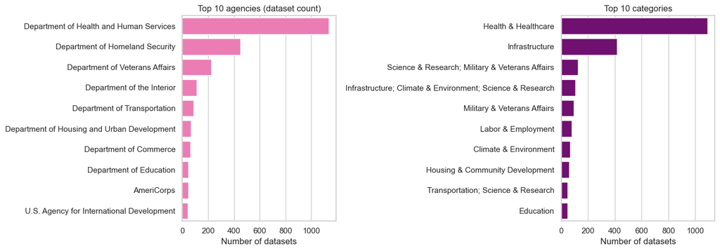

```python
fig, axes = plt.subplots(1, 2, figsize=(14, 5))

# Top agencies
agencies = df_drp['agency'].value_counts()
top_agencies = agencies.head(10)
sns.barplot(x=top_agencies.values, y=top_agencies.index, ax=axes[0], color='hotpink')
axes[0].set_title('Top 10 agencies (dataset count)')
axes[0].set_xlabel('Number of datasets')
axes[0].set_ylabel('')

# Top categories
cats = df_drp['category'].value_counts()
top_cats = cats.head(10)
sns.barplot(x=top_cats.values, y=top_cats.index, ax=axes[1], color='purple')
axes[1].set_title('Top 10 categories')
axes[1].set_xlabel('Number of datasets')
axes[1].set_ylabel('')

plt.tight_layout()
plt.show()
```

```python
print(f'Agencies: {len(agencies)}, only one: {(agencies == 1).mean():.3g}')
print(f'Top 1: {top_agencies.index[0], top_agencies.iloc[0]}')

print(f'Categories: {len(cats)}, only one: {(cats == 1).mean():.3g}')
print(f'Top 1: {top_cats.index[0], top_cats.iloc[0]}')
```

```
Agencies: 34, only one: 0.147
Top 1: ('Department of Health and Human Services', 1135)
Categories: 44, only one: 0.205
Top 1: ('Health & Healthcare', 1091)
```

DRP data includes 34 federal agencies in total, wich 14.7% being represented by only one example. Department of Health and Human Services is the largest one, with 1135 examples.

These represent a total of 44 categories of datasets, with the most common one being Health & Healthcare (1091 samples).

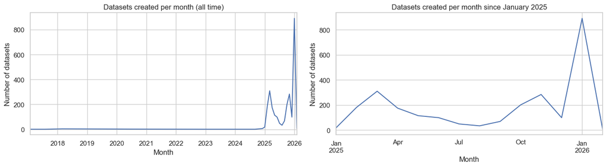

```python
dc_created = pd.to_datetime(df_drp['dc_created'], errors='coerce').dt.to_period('M')

fig, axes = plt.subplots(1, 2, figsize=(14, 4))

dc_created.value_counts().sort_index().plot(ax=axes[0])
axes[0].set_title('Datasets created per month (all time)')
axes[0].set_xlabel('Month')
axes[0].set_ylabel('Number of datasets')

dc_created[dc_created >= '2025-01'].value_counts().sort_index().plot(ax=axes[1])
axes[1].set_title('Datasets created per month since January 2025')
axes[1].set_xlabel('Month')
axes[1].set_ylabel('Number of datasets')

plt.tight_layout()
plt.show()
```

Most datasets in DRP have a publishing date in 2025, which indicates that it's not the original publishing date but a date of republishing on DRP - it conceals some of the original dataset information.

```python
df_drp['dc_isActive'].value_counts()
```

```
dc_isActive
True    2539
Name: count, dtype: int64
```

Activity flag is true for all datasets, also because of using the republished DOI, not the original one.

### Textual features

```python
df_drp['abstract_word_count'] = df_drp['dc_abstract'].fillna('').astype(str).str.split().str.len()
df_drp['title_word_count'] = df_drp['title'].fillna('').astype(str).str.split().str.len()
```

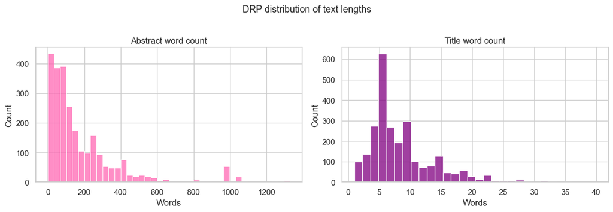

```python
fig, axes = plt.subplots(1, 2, figsize=(12, 4))

sns.histplot(data=df_drp[df_drp['abstract_word_count'] <= 1500], x='abstract_word_count', bins=40, ax=axes[0], color='hotpink')
axes[0].set_title(f'Abstract word count')
axes[0].set_xlabel('Words')

sns.histplot(data=df_drp, x='title_word_count', bins=30, ax=axes[1], color='purple')
axes[1].set_title('Title word count')
axes[1].set_xlabel('Words')

plt.suptitle('DRP distribution of text lengths', fontsize=13, y=1.02)
plt.tight_layout()
plt.show()
```

Abstract word counts range from 1 to 9262 words, with mean of 195.8. The distribution is heavily right-skewed - data is dominated by shorted abstracts. There's 8 outliers (above 1500), not included on the plot for readability.

Titles word counts range from 1 word to 40, with mean of 8.5. The distribution is also right-skewed, but not as heavily as abstracts.

### Flagged words

```python
counts_flagged = df_drp['has_flagged_word_total'].value_counts().rename({0: 'Not flagged', 1: 'Flagged'})
print(counts_flagged)
print(f'\nProportion flagged: {counts_flagged.get("Flagged", 0) / len(df_drp):.2}')
```

```
has_flagged_word_total
Not flagged    1359
Flagged        1180
Name: count, dtype: int64

Proportion flagged: 0.46
```

Only 46.5% of datasets in DRP contain flagged words, which makes sense considering DRP data gathering methodology. They rely not only on banned terms identified by journalists and scientists, but also on tips from insiders or specific agencies targeted by the government, so a lot of rescued data wouldn't necessarily contain sensitive language.

```python
num_cols_drp = ['abstract_word_count', 'title_word_count',
               'num_flagged_words', 'num_flagged_words_title', 'num_flagged_words_total',
               'dc_viewCount', 'dc_downloadCount', 'dc_citationCount']
df_drp[[c for c in num_cols_drp if c in df_drp.columns]].describe().T.style.format('{:,.2f}')
```

|  | count | mean | std | min | 25% | 50% | 75% | max |
| --- | --- | --- | --- | --- | --- | --- | --- | --- |
| abstract_word_count | 2,539.00 | 195.76 | 329.61 | 1.00 | 53.00 | 108.00 | 244.00 | 9,262.00 |
| title_word_count | 2,539.00 | 8.49 | 5.29 | 1.00 | 5.00 | 7.00 | 11.00 | 40.00 |
| num_flagged_words | 2,539.00 | 0.91 | 1.31 | 0.00 | 0.00 | 0.00 | 2.00 | 10.00 |
| num_flagged_words_title | 2,539.00 | 0.25 | 0.66 | 0.00 | 0.00 | 0.00 | 0.00 | 5.00 |
| num_flagged_words_total | 2,539.00 | 1.17 | 1.71 | 0.00 | 0.00 | 0.00 | 2.00 | 11.00 |
| dc_viewCount | 2,539.00 | 2.06 | 30.26 | 0.00 | 0.00 | 0.00 | 0.00 | 1,170.00 |
| dc_downloadCount | 2,539.00 | 0.41 | 7.80 | 0.00 | 0.00 | 0.00 | 0.00 | 361.00 |
| dc_citationCount | 2,539.00 | 0.05 | 0.33 | 0.00 | 0.00 | 0.00 | 0.00 | 10.00 |

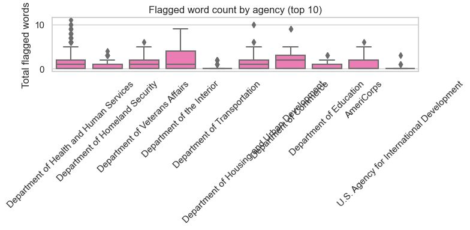

```python
fig, ax = plt.subplots(figsize=(8, 4))

top_agency_names = df_drp['agency'].value_counts().head(10).index
drp_top = df_drp[df_drp['agency'].isin(top_agency_names)]

sns.boxplot(data=drp_top, x='agency', y='num_flagged_words_total', order=top_agency_names, ax=ax, color='hotpink')
ax.tick_params(axis='x', rotation=45)
ax.set_title('Flagged word count by agency (top 10)')
ax.set_xlabel('')
ax.set_ylabel('Total flagged words')
plt.tight_layout()
plt.show()
```

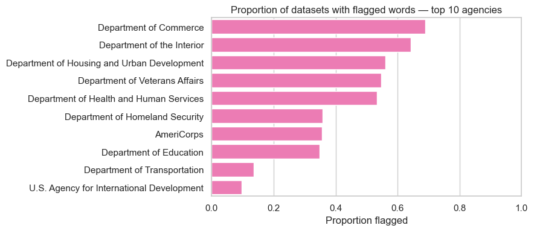

```python
flag_by_agency = (
    drp_top.groupby('agency')['has_flagged_word_total']
    .mean()
    .reindex(top_agency_names)
    .sort_values(ascending=False)
)

fig, ax = plt.subplots(figsize=(9, 4))
sns.barplot(x=flag_by_agency.values, y=flag_by_agency.index, ax=ax, color='hotpink')
ax.set_title('Proportion of datasets with flagged words — top 10 agencies')
ax.set_xlabel('Proportion flagged')
ax.set_ylabel('')
ax.set_xlim(0, 1)
plt.tight_layout()
plt.show()
```

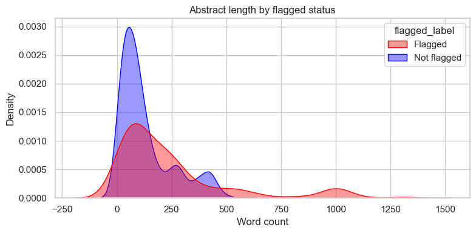

```python
fig, ax = plt.subplots(figsize=(8, 4))

df_drp['flagged_label'] = df_drp['has_flagged_word_total'].map({0: 'Not flagged', 1: 'Flagged'})
drp_capped = df_drp[df_drp['abstract_word_count'] <= 1500]

sns.kdeplot(data=drp_capped, x='abstract_word_count', hue='flagged_label',
            fill=True, alpha=0.4, ax=ax,
            palette={'Not flagged': 'blue', 'Flagged': 'red'})

ax.set_title('Abstract length by flagged status')
ax.set_xlabel('Word count')
ax.set_ylabel('Density')
plt.tight_layout()
plt.show()
```

There is an overlap between flagged and non-flagged abstracts, but the shapes are noticably different. Non-flagged abstracts are shorter with peak around 75 words. Flagged abstracts spread out more evenly up to 500+ words. However, longer abstracts naturally also provide more opportunity for flagged words to appear, which might be confusing for the future model.

The metadata based on DOI identifiers from DRP is related to republishing, and some of it's abstracts/notes reveal that it has been included in the project and introduces leakage to any modeling that would utilize textual features.

To address this, each DRP dataset is being matched to its original state using [Data.gov](https://data.gov), the largest federal repository of datasets, and its Harvard mirror. This will provide pre-rescue metadata as model features and a better basis for constructing negative examples.